# daily-predictive-modelling

Alejandro Cadavid Romero

Universidad Nacional de Colombia  
alcadavidro@unal.edu.co

Santiago Vasquez Rodriguez

Universidad Nacional de Colombia  
svasquezro@unal.edu.co

# Introducción

Este documento hace parte del trabajo del curso de **Analítica Predictiva** de la Universidad Nacional de Colombia para la Maestría en Ingeniería y Especialización en Analítica. El alcance de este es la creación de modelos predictivos para la estimación de cantidad de accidentes en el valle del aburra a nivel diario.

### Carga de librerias

```r
# Manipulación de datos
library(dplyr)
library(tidyr)
library(lubridate)
# Modelado de datos
library(recipes)
library(Metrics)
library(glmnet)
library(caret)
library(MASS)
```

```r
# Visualización
library(ggplot2)

# Formato tablas
library(kableExtra)
```

### Carga de datos

```r
df_train <- read.csv('../../data/processed/train_data.csv')
df_test <- read.csv('../../data/processed/test_data.csv')
special_dates_train <- read.csv('../../data/processed/special_date_monthly_2017.csv')
special_dates_test <- read.csv('../../data/processed/special_date_monthly_2018.csv')
```

```r
kable(head(df_train)) %>%
  kable_styling(bootstrap_options = "striped", full_width = F) %>%
  scroll_box(width = "100%")
```

| X | DIA | PERIODO | CLASE | DIRECCION | DIRECCION_ENC | CBML | TIPO_GEOCOD | GRAVEDAD | BARRIO | COMUNA | DISENO | DIA_NOMBRE | MES | LONGITUD | LATITUD | FECHA |
| --- | --- | --- | --- | --- | --- | --- | --- | --- | --- | --- | --- | --- | --- | --- | --- | --- |
| 1 | 1 | 2014 | choque | cr 63 cl 94 | cr 063 094 000 00000 |  | no ubicada | solo danos |  |  | tramo de via | miercoles | 1 | -75.70382 | 6.221806 | 2014-01-01 19:00:00 |
| 2 | 1 | 2014 | choque | cl 30 cr 66 b | cl 030 066 b 000 00000 | 1602 | malla vial | solo danos | rosales | belen | interseccion | miercoles | 1 | -75.58727 | 6.231716 | 2014-01-01 07:40:00 |
| 3 | 1 | 2014 | choque | cr 52 cl 97 | cr 052 097 000 00000 | 0402 | malla vial | solo danos | san isidro | aranjuez | interseccion | miercoles | 1 | -75.56253 | 6.289907 | 2014-01-01 05:30:00 |
| 4 | 1 | 2014 | choque | tv 78 cl 65 | tv 078 065 000 00000 | 0519 | malla vial | solo danos | el progreso | castilla | tramo de via | miercoles | 1 | -75.57365 | 6.275473 | 2014-01-01 13:50:00 |
| 5 | 1 | 2014 | otro | cr 63 cl 50 | cr 063 050 000 00000 | 1101 | malla vial | solo danos | carlos e. restrepo | laureles estadio | tramo de via | miercoles | 1 | -75.57697 | 6.255457 | 2014-01-01 07:25:00 |
| 6 | 1 | 2014 | choque | cr 57 cl 51 | cr 057 051 000 00000 | 1006 | malla vial | solo danos | san benito | la candelaria | tramo de via | miercoles | 1 | -75.57481 | 6.254322 | 2014-01-01 04:15:00 |

# Armado del conjunto de datos

Debido a que se deben armar ciertas agregaciones a nivel de conjunto de datos antes de crear los datasets de entrenamiento, se incluye una etapa de armado del conjunto de variables, no está asociado directamente con la limpieza de los datos. La base que se construye a continuación serán los cimientos para el modelo el modelo diario.

```r
df <- rbind(
  df_train,
  df_test
)
special_dates_train <- special_dates_train %>%
  dplyr::select(PERIODO, MES, DIA, DIA_FESTIVO, FECHA_ESPECIAL, FESTIVO_FECHA_ESPECIAL)
special_dates_test <- special_dates_test %>%
  dplyr::select(PERIODO, MES, DIA, DIA_FESTIVO, FECHA_ESPECIAL, FESTIVO_FECHA_ESPECIAL)

special_dates <- rbind(
  special_dates_train,
  special_dates_test
) %>% distinct()

df <- merge(df, special_dates, by = c("PERIODO", "MES", "DIA"))

kable(head(df)) %>%
  kable_styling(bootstrap_options = "striped", full_width = F) %>%
  scroll_box(width = "100%")
```

| PERIODO | MES | DIA | X | CLASE | DIRECCION | DIRECCION_ENC | CBML | TIPO_GEOCOD | GRAVEDAD | BARRIO | COMUNA | DISENO | DIA_NOMBRE | LONGITUD | LATITUD | FECHA | DIA_FESTIVO | FECHA_ESPECIAL | FESTIVO_FECHA_ESPECIAL |
| --- | --- | --- | --- | --- | --- | --- | --- | --- | --- | --- | --- | --- | --- | --- | --- | --- | --- | --- | --- |
| 2014 | 1 | 1 | 1 | choque | cr 63 cl 94 | cr 063 094 000 00000 |  | no ubicada | solo danos |  |  | tramo de via | miercoles | -75.70382 | 6.221806 | 2014-01-01 19:00:00 | 1 | 1 | 1 |
| 2014 | 1 | 1 | 2 | choque | cl 30 cr 66 b | cl 030 066 b 000 00000 | 1602 | malla vial | solo danos | rosales | belen | interseccion | miercoles | -75.58727 | 6.231716 | 2014-01-01 07:40:00 | 1 | 1 | 1 |
| 2014 | 1 | 1 | 3 | choque | cr 52 cl 97 | cr 052 097 000 00000 | 0402 | malla vial | solo danos | san isidro | aranjuez | interseccion | miercoles | -75.56253 | 6.289907 | 2014-01-01 05:30:00 | 1 | 1 | 1 |
| 2014 | 1 | 1 | 4 | choque | tv 78 cl 65 | tv 078 065 000 00000 | 0519 | malla vial | solo danos | el progreso | castilla | tramo de via | miercoles | -75.57365 | 6.275473 | 2014-01-01 13:50:00 | 1 | 1 | 1 |
| 2014 | 1 | 1 | 5 | otro | cr 63 cl 50 | cr 063 050 000 00000 | 1101 | malla vial | solo danos | carlos e. restrepo | laureles estadio | tramo de via | miercoles | -75.57697 | 6.255457 | 2014-01-01 07:25:00 | 1 | 1 | 1 |
| 2014 | 1 | 1 | 6 | choque | cr 57 cl 51 | cr 057 051 000 00000 | 1006 | malla vial | solo danos | san benito | la candelaria | tramo de via | miercoles | -75.57481 | 6.254322 | 2014-01-01 04:15:00 | 1 | 1 | 1 |

# Modelado diario

## Clase choque

### Preprocesamiento de datos

```r
armado_dataset_diario <- function(df, objective_var){
  # conjunto de datos diario por clase
  accidentes_por_clase <- df %>%
    group_by(PERIODO, MES, DIA, CLASE) %>%
    summarise(n_accidentes=n(), .groups="drop") %>%
    spread(CLASE, n_accidentes) %>%
    mutate(PERIODO_LEAD=lead(PERIODO), MES_LEAD=lead(MES), DIA_LEAD=lead(DIA), rank = 1:length(PERIODO)) %>%
    filter(rank < max(rank)) %>%
    dplyr::select(-c(PERIODO, MES, DIA, rank))

  # conjunto de datos dia por gravedad
  accidentes_por_gravedad <- df %>%
    group_by(PERIODO, MES, DIA, GRAVEDAD) %>%
    summarise(n_accidentes=n(), .groups="drop") %>%
    spread(GRAVEDAD, n_accidentes) %>%
    mutate(PERIODO_LEAD=lead(PERIODO), MES_LEAD=lead(MES), DIA_LEAD=lead(DIA), rank = 1:length(PERIODO)) %>%
    filter(rank < max(rank)) %>%
    dplyr::select(-c(PERIODO, MES, DIA, rank))

  accidentes_por_hora <- df %>% mutate(HORA=hour(FECHA)) %>%
    mutate(
      temprano=ifelse(HORA %in% c(1,2,3,4,5,6), 1, 0),
      temprano_trabajo=ifelse(HORA %in% c(7,8,9,10,11,12), 1,0),
      almuerzo=ifelse(HORA == 13, 1, 0),
      tarde=ifelse(HORA %in% c(14,15,16,17,18), 1, 0),
      noche=ifelse(HORA %in% c(19, 20, 21, 22, 23, 24), 1,0)
      ) %>%
    group_by(PERIODO, MES, DIA) %>%
    summarise(
      accidentes_temprano=sum(temprano),
      accidentes_temprano_trabajo=sum(temprano_trabajo),
      accidentes_almuerzo=sum(almuerzo),
      accidentes_tarde=sum(tarde),
      accidentes_noche=sum(noche),
      .groups="drop"
    ) %>%
  mutate(PERIODO_LEAD=lead(PERIODO), MES_LEAD=lead(MES), DIA_LEAD=lead(DIA), rank = 1:length(PERIODO)) %>%
    filter(rank < max(rank)) %>%
    dplyr::select(-c(PERIODO, MES, DIA, rank))

  # rezagos de la clase
  rezagos_accidentes <- df %>%
    filter(CLASE == objective_var) %>%
    group_by(PERIODO, MES, DIA) %>%
    summarise(n_accidentes=n(), .groups="drop") %>%
    mutate(
      FECHA=as.Date(paste(PERIODO, formatC(MES, width = 2, flag = "0"), formatC(DIA, width = 2, flag = "0"), sep='-')),
      t_minus_1=lag(n_accidentes, n = 1),
      t_minus_2=lag(n_accidentes, n = 2),
      t_minus_3=lag(n_accidentes, n = 3),
      t_minus_4=lag(n_accidentes, n = 4),
      t_minus_5=lag(n_accidentes, n = 5),
      t_minus_6=lag(n_accidentes, n = 6),
    ) %>%
    dplyr::select(PERIODO, MES, DIA, t_minus_2, t_minus_3, t_minus_4, t_minus_5, t_minus_6)

  # Accidentes en los domingos
  domingos <- df %>%
    mutate(domingo = ifelse(DIA_NOMBRE == "domingo  ", 1, 0)) %>%
    group_by(PERIODO, MES, DIA) %>%
    summarise(accidentes_domingo=sum(domingo), .groups="drop") %>%
    mutate(PERIODO_LEAD=lead(PERIODO), MES_LEAD=lead(MES), DIA_LEAD=lead(DIA), rank = 1:length(PERIODO)) %>%
    filter(rank < max(rank)) %>%
    dplyr::select(-c(PERIODO, MES, DIA, rank))

  # Union del df
  df_processed <- df %>%
    filter(CLASE == objective_var) %>%
    group_by(PERIODO, MES, DIA) %>%
    summarise(
      numero_accidentes = n(),
      .groups="drop"
    ) %>%
    mutate(
      DIA=factor(DIA),
      MES=factor(MES)
      ) %>%
    merge(accidentes_por_clase,
          by.x = c("PERIODO", "MES", "DIA"), by.y = c("PERIODO_LEAD", "MES_LEAD", "DIA_LEAD"), all.x = T) %>%
    merge(accidentes_por_gravedad,
          by.x = c("PERIODO", "MES", "DIA"), by.y = c("PERIODO_LEAD", "MES_LEAD", "DIA_LEAD"), all.x = T) %>%
    merge(rezagos_accidentes,
          by.x = c("PERIODO", "MES", "DIA"), by.y = c("PERIODO", "MES", "DIA"), all.x = T) %>%
    merge(domingos,
          by.x = c("PERIODO", "MES", "DIA"), by.y = c("PERIODO_LEAD", "MES_LEAD", "DIA_LEAD"), all.x = T) %>%
    merge(special_dates,
          by = c("PERIODO", "MES", "DIA")) %>%
    merge(accidentes_por_hora,
          by.x = c("PERIODO", "MES", "DIA"), by.y = c("PERIODO_LEAD", "MES_LEAD", "DIA_LEAD"), all.x = T) %>%
    mutate(
      DIA_FESTIVO=factor(DIA_FESTIVO),
      FECHA_ESPECIAL=factor(FECHA_ESPECIAL),
      FESTIVO_FECHA_ESPECIAL=factor(FESTIVO_FECHA_ESPECIAL)
      ) %>%
    arrange(PERIODO, MES, DIA, .by_group = T) %>%
    filter(!is.na(t_minus_6)) %>%
    replace_na(list(incendio=0, muerto=0, volcamiento=0)) %>%
    mutate(
      DIA_SEMANA = factor(wday(
        as_date(
          paste(
            PERIODO, formatC(MES, width = 2, flag = 0), formatC(DIA, width = 2, flag = 0), sep='-')
        )
      )
      )
    )

  return(df_processed)
}
```

Se procede a realizar la construcción del conjunto de datos para la clase choque y hacer todo el pipeline de preprocesamiento para implementar el escalado y estandarización al conjunto de entrenamiento y validación.

```r
df_preprocessed <- armado_dataset_diario(df=df, objective_var = "choque")
df_choque_train <- df_preprocessed %>% filter(PERIODO!=2018) %>% dplyr::select(-c(PERIODO, DIA))
df_choque_test <- df_preprocessed %>% filter(PERIODO==2018) %>% dplyr::select(-c(PERIODO, DIA))

model.choque.recipe <- recipe(numero_accidentes ~ .,
                              data = df_choque_train)
model.choque.steps <- model.choque.recipe %>%
  step_log(all_outcomes()) %>%
  step_center(all_predictors(), -MES, -DIA_SEMANA, -DIA_FESTIVO, -FECHA_ESPECIAL, -FESTIVO_FECHA_ESPECIAL) %>%
  step_scale(all_predictors(), -MES, -DIA_SEMANA, -DIA_FESTIVO, -FECHA_ESPECIAL, -FESTIVO_FECHA_ESPECIAL)

model.choque.prepared <- prep(model.choque.steps, training = df_choque_train)
df_choque_train <- bake(model.choque.prepared, df_choque_train)
df_choque_test <- bake(model.choque.prepared, df_choque_test)
```

### Modelamiento

#### Regresión lineal simple

Como primer intento, vale la pena evaluar un modelo de regresión lineal simple con stepwise variable selection para descartar variables que no entreguen valor.

```r
modelo.choque <- lm(numero_accidentes ~ ., data=df_choque_train)
step.model.choque <- stepAIC(modelo.choque, direction = "both", trace = F, steps = 2000)

model.choque.summary <- summary(step.model.choque)
model.choque.summary
```

```
##
## Call:
## lm(formula = numero_accidentes ~ MES + `caida ocupante` + choque +
##     otro + t_minus_2 + t_minus_3 + t_minus_4 + t_minus_5 + t_minus_6 +
##     DIA_FESTIVO + FESTIVO_FECHA_ESPECIAL + DIA_SEMANA, data = df_choque_train)
##
## Residuals:
##      Min       1Q   Median       3Q      Max
## -1.03751 -0.08680  0.00437  0.10475  0.82881
##
## Coefficients:
##                          Estimate Std. Error t value Pr(>|t|)
## (Intercept)              3.817669   0.020152 189.440  < 2e-16 ***
## MES2                     0.092665   0.024103   3.845 0.000126 ***
## MES3                     0.100110   0.023348   4.288 1.93e-05 ***
## MES4                     0.087314   0.023050   3.788 0.000158 ***
## MES5                     0.098930   0.023629   4.187 3.00e-05 ***
## MES6                     0.084458   0.022909   3.687 0.000236 ***
## MES7                     0.108122   0.022808   4.741 2.34e-06 ***
## MES8                     0.100754   0.023992   4.200 2.84e-05 ***
## MES9                     0.097070   0.024088   4.030 5.88e-05 ***
## MES10                    0.096701   0.023222   4.164 3.31e-05 ***
## MES11                    0.098616   0.023223   4.246 2.31e-05 ***
## MES12                    0.082832   0.023468   3.530 0.000430 ***
## `caida ocupante`         0.007982   0.004684   1.704 0.088549 .
## choque                   0.035429   0.006490   5.459 5.63e-08 ***
## otro                     0.007042   0.004704   1.497 0.134572
## t_minus_2                0.028963   0.006363   4.552 5.76e-06 ***
## t_minus_3                0.019719   0.006395   3.084 0.002085 **
## t_minus_4                0.017344   0.006410   2.706 0.006892 **
## t_minus_5                0.012954   0.006398   2.025 0.043071 *
## t_minus_6                0.010533   0.006367   1.654 0.098301 .
## DIA_FESTIVO1            -0.705518   0.032015 -22.037  < 2e-16 ***
## FESTIVO_FECHA_ESPECIAL1  0.113555   0.041489   2.737 0.006277 **
## DIA_SEMANA2              0.642780   0.020598  31.205  < 2e-16 ***
## DIA_SEMANA3              0.652417   0.021727  30.028  < 2e-16 ***
## DIA_SEMANA4              0.598663   0.020491  29.216  < 2e-16 ***
## DIA_SEMANA5              0.568465   0.021173  26.849  < 2e-16 ***
## DIA_SEMANA6              0.654000   0.021215  30.827  < 2e-16 ***
## DIA_SEMANA7              0.490743   0.019805  24.779  < 2e-16 ***
## ---
## Signif. codes:  0 '***' 0.001 '**' 0.01 '*' 0.05 '.' 0.1 ' ' 1
##
## Residual standard error: 0.1684 on 1427 degrees of freedom
## Multiple R-squared:  0.7105, Adjusted R-squared:  0.705
## F-statistic: 129.7 on 27 and 1427 DF,  p-value: < 2.2e-16
```

```r
plot_estimation_errors <- function(y_true, y_pred, title){
  min_value <- min(y_true, y_pred) - min(y_true, y_pred) * 0.1
  max_value <- max(y_true, y_pred) + max(y_true, y_pred) * 0.1

  plot(x=y_true,y=y_pred,
       ylab="Predicciones",xlab="Observados",
       xlim=c(min_value, max_value),ylim=c(min_value, max_value),
       las=1, cex=1, pch=16,
       main=title)
  abline(a=0,b=1,lwd=2,col="black", lty=2)
  R_vl<-cor(y_pred, y_true)
  R_vl<-format(R_vl, digits = 3, nsmall = 3)
  rmse_vl<- rmse(actual = y_true, predicted = y_pred)
  rmse_vl<-format(rmse_vl,digits = 3,nsmall = 2)
  grid()
  legend("topleft",legend=paste0(c("Correlación: ","RMSE: "),c(R_vl,rmse_vl)), bty="n")
}
```

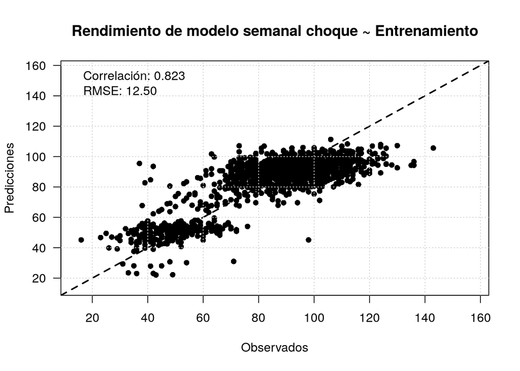

```r
y_pred <- exp(predict(step.model.choque, df_choque_train))
y_true <- exp(df_choque_train$numero_accidentes)

train_rmse <- rmse(y_true, y_pred)

plot_estimation_errors(
  y_true = y_true,
  y_pred = y_pred,
  title="Rendimiento de modelo semanal choque ~ Entrenamiento"
  )
```

De primera instancia, se observa un muy buen ajuste de los datos de entrenamiento respecto al modelo de regresión lineal, sin embargo, para evaluar su capacidad de generalizar es necesario evaluarlo en el conjunto de validación.

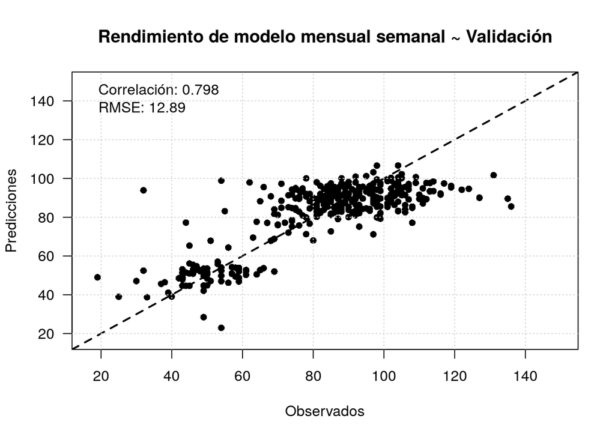

```r
y_pred <- exp(predict(step.model.choque, df_choque_test))
y_true <- exp(df_choque_test$numero_accidentes)

test_rmse <- rmse(y_true, y_pred)

test_train_ratio <- round(((test_rmse / train_rmse) - 1)*100, 3)

plot_estimation_errors(
  y_true = y_true,
  y_pred = y_pred,
  title="Rendimiento de modelo mensual semanal ~ Validación"
  )
```

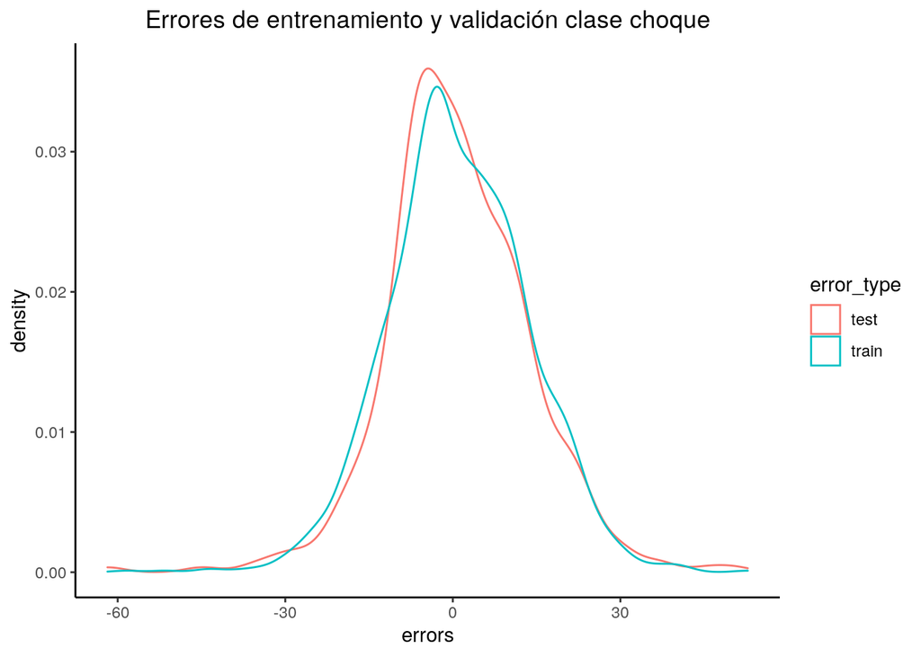

```r
plot_errors_density <- function(model, train, y_train, test, y_test, title){
  # data extraction
  y_pred <- exp(predict(model, train))
  y_true <- exp(y_train)
  train_error <- y_true - y_pred
  y_pred <- exp(predict(model, test))
  y_true <- exp(y_test)
  test_error <- y_true - y_pred
  #errors dataframe
  errors_df <- data.frame(
    errors = c(train_error, test_error),
    error_type = c(
      rep("train", length(train_error)),
      rep("test", length(test_error))
    )
  )
  # plotting
  ggplot(errors_df, aes(x=errors, color=error_type)) +
    geom_density() +
    theme_classic() +
    ggtitle(title) +
    theme(plot.title = element_text(hjust = 0.5))
}

plot_errors_density(
  model = step.model.choque,
  train = df_choque_train,
  y_train = df_choque_train$numero_accidentes,
  test = df_choque_test,
  y_test = df_choque_test$numero_accidentes,
  title="Errores de entrenamiento y validación clase choque"
  )
```

Del análisis de errores, es claro que el modelo tiene problemas de subestimación, ya que las estimaciones no superan los valores de aproximadamente 120 choques por día. Sin embargo, viendo justamente los datos, es una proporción pequeña respecto a todo el conjunto de datos, por lo que podrían denotarse como observaciones más atípicas.

### Clase atropello

#### Regresión lineal

```r
df_preprocessed <- armado_dataset_diario(df=df, objective_var = "atropello")
df_atropello_train <- df_preprocessed %>% filter(PERIODO!=2018) %>% dplyr::select(-c(PERIODO, DIA))
df_atropello_test <- df_preprocessed %>% filter(PERIODO==2018) %>% dplyr::select(-c(PERIODO, DIA))

model.atropello.recipe <- recipe(numero_accidentes ~ .,
                              data = df_atropello_train)
model.atropello.steps <- model.atropello.recipe %>%
  step_log(all_outcomes()) %>%
  step_center(all_predictors(), -MES, -DIA_SEMANA, -DIA_FESTIVO, -FECHA_ESPECIAL, -FESTIVO_FECHA_ESPECIAL) %>%
  step_scale(all_predictors(), -MES, -DIA_SEMANA, -DIA_FESTIVO, -FECHA_ESPECIAL, -FESTIVO_FECHA_ESPECIAL)

model.atropello.prepared <- prep(model.atropello.steps, training = df_atropello_train)
df_atropello_train <- bake(model.atropello.prepared, df_atropello_train)
df_atropello_test <- bake(model.atropello.prepared, df_atropello_test)
```

```r
modelo.atropello <- lm(numero_accidentes ~ ., data=df_atropello_train)
step.model.atropello <- stepAIC(modelo.atropello, direction = "both", trace = F, steps = 2000)

model.atropello.summary <- summary(step.model.atropello)
model.atropello.summary
```

```
##
## Call:
## lm(formula = numero_accidentes ~ `caida ocupante` + otro + volcamiento +
##     herido + muerto + t_minus_2 + t_minus_3 + t_minus_4 + t_minus_5 +
##     t_minus_6 + accidentes_domingo + DIA_FESTIVO + accidentes_temprano +
##     accidentes_almuerzo + DIA_SEMANA, data = df_atropello_train)
##
## Residuals:
##      Min       1Q   Median       3Q      Max
## -2.26655 -0.20056  0.03529  0.23670  1.09328
##
## Coefficients:
##                      Estimate Std. Error t value Pr(>|t|)
## (Intercept)          2.434403   0.034623  70.313  < 2e-16 ***
## `caida ocupante`     0.024239   0.011426   2.121  0.03406 *
## otro                -0.036975   0.011835  -3.124  0.00182 **
## volcamiento         -0.029113   0.010150  -2.868  0.00419 **
## herido               0.031515   0.016813   1.874  0.06107 .
## muerto               0.023293   0.009307   2.503  0.01243 *
## t_minus_2            0.028537   0.009671   2.951  0.00322 **
## t_minus_3            0.014402   0.009681   1.488  0.13707
## t_minus_4            0.024836   0.009653   2.573  0.01018 *
## t_minus_5            0.016426   0.009644   1.703  0.08874 .
## t_minus_6            0.029651   0.009642   3.075  0.00214 **
## accidentes_domingo   0.127255   0.059204   2.149  0.03177 *
## DIA_FESTIVO1        -0.210127   0.043343  -4.848 1.38e-06 ***
## accidentes_temprano  0.034444   0.013456   2.560  0.01058 *
## accidentes_almuerzo  0.030982   0.013601   2.278  0.02288 *
## DIA_SEMANA2         -0.293228   0.174862  -1.677  0.09378 .
## DIA_SEMANA3          0.093196   0.035739   2.608  0.00921 **
## DIA_SEMANA4          0.064353   0.035471   1.814  0.06985 .
## DIA_SEMANA5          0.072045   0.035375   2.037  0.04187 *
## DIA_SEMANA6          0.160591   0.035983   4.463 8.72e-06 ***
## DIA_SEMANA7          0.230033   0.034915   6.588 6.23e-11 ***
## ---
## Signif. codes:  0 '***' 0.001 '**' 0.01 '*' 0.05 '.' 0.1 ' ' 1
##
## Residual standard error: 0.3488 on 1434 degrees of freedom
## Multiple R-squared:  0.1371, Adjusted R-squared:  0.1251
## F-statistic: 11.39 on 20 and 1434 DF,  p-value: < 2.2e-16
```

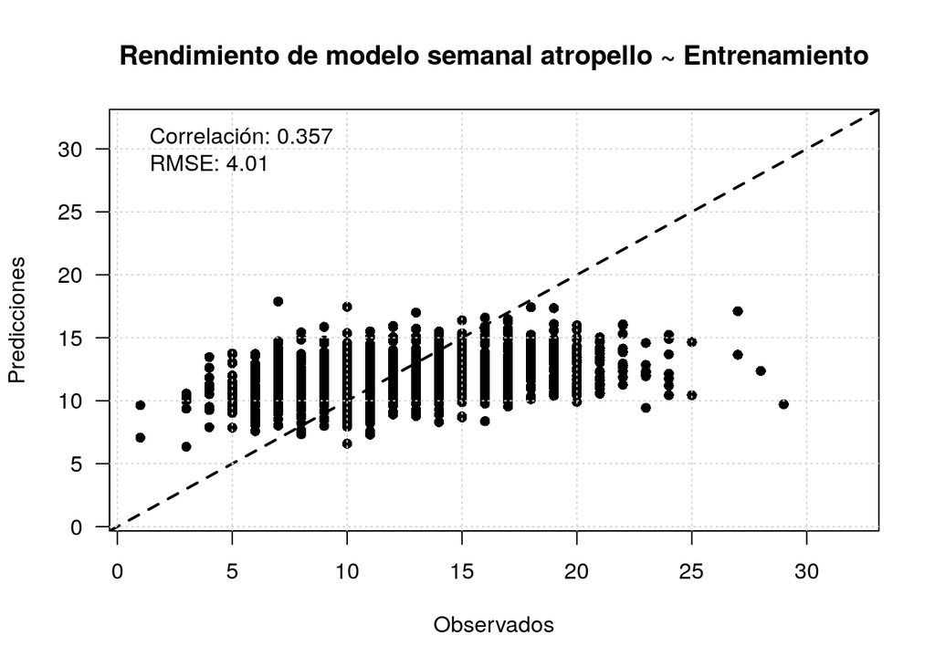

```r
y_pred <- exp(predict(step.model.atropello, df_atropello_train))
y_true <- exp(df_atropello_train$numero_accidentes)

train_rmse <- rmse(y_true, y_pred)

plot_estimation_errors(
  y_true = y_true,
  y_pred = y_pred,
  title="Rendimiento de modelo semanal atropello ~ Entrenamiento"
  )
```

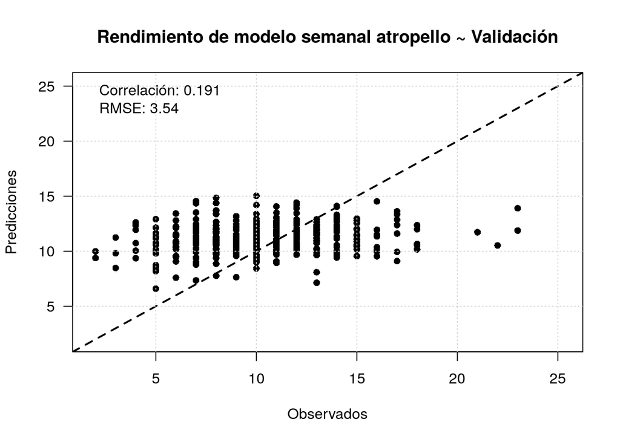

```r
y_pred <- exp(predict(step.model.atropello, df_atropello_test))
y_true <- exp(df_atropello_test$numero_accidentes)

train_rmse <- rmse(y_true, y_pred)

plot_estimation_errors(
  y_true = y_true,
  y_pred = y_pred,
  title="Rendimiento de modelo semanal atropello ~ Validación"
  )
```

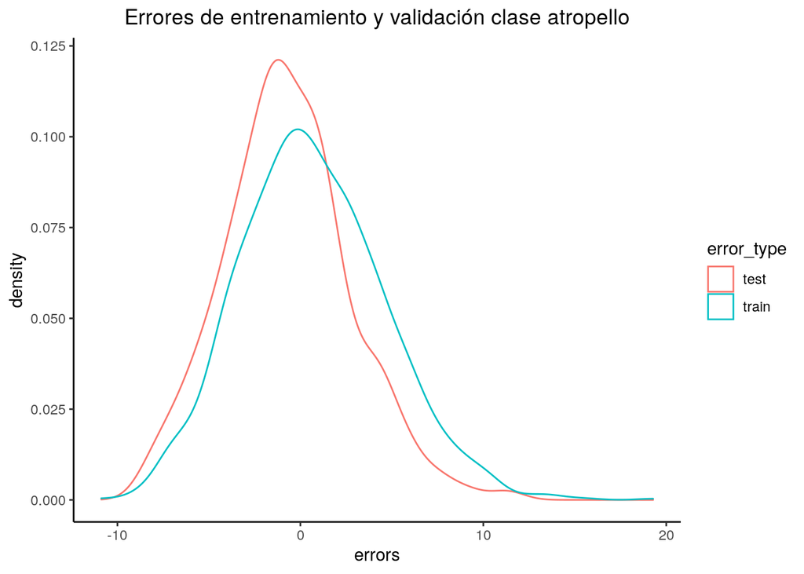

```r
plot_errors_density(
  model = step.model.atropello,
  train = df_atropello_train,
  y_train = df_atropello_train$numero_accidentes,
  test = df_atropello_test,
  y_test = df_atropello_test$numero_accidentes,
  title="Errores de entrenamiento y validación clase atropello"
  )
```

El modelo de regresión lineal claramente no se ajusta correctamente a los datos, una de las soluciones puede ser incorporar nuevas variables que logren explicar mejor la variabilidad del fenomeno a estudiar o intentar con modelos diferentes que logren generalizar mejor la variable respuesta.

### Clase caida ocupante

#### Regresión lineal

```r
df_preprocessed <- armado_dataset_diario(df=df, objective_var = "caida ocupante")
df_caida_ocupante_train <- df_preprocessed %>% filter(PERIODO!=2018) %>% dplyr::select(-c(PERIODO, DIA))
df_caida_ocupante_test <- df_preprocessed %>% filter(PERIODO==2018) %>% dplyr::select(-c(PERIODO, DIA))

model.caida_ocupante.recipe <- recipe(numero_accidentes ~ .,
                              data = df_caida_ocupante_train)
model.caida_ocupante.steps <- model.caida_ocupante.recipe %>%
  step_log(all_outcomes()) %>%
  step_center(all_predictors(), -MES, -DIA_SEMANA, -DIA_FESTIVO, -FECHA_ESPECIAL, -FESTIVO_FECHA_ESPECIAL) %>%
  step_scale(all_predictors(), -MES, -DIA_SEMANA, -DIA_FESTIVO, -FECHA_ESPECIAL, -FESTIVO_FECHA_ESPECIAL)

model.caida_ocupante.prepared <- prep(model.caida_ocupante.steps, training = df_caida_ocupante_train)
df_caida_ocupante_train <- bake(model.caida_ocupante.prepared, df_caida_ocupante_train)
df_caida_ocupante_test <- bake(model.caida_ocupante.prepared, df_caida_ocupante_test)
```

```r
modelo.caida_ocupante <- lm(numero_accidentes ~ ., data=df_caida_ocupante_train)
step.model.caida_ocupante <- stepAIC(modelo.caida_ocupante, direction = "both", trace = F, steps = 2000)

model.caida_ocupante.summary <- summary(step.model.caida_ocupante)
model.caida_ocupante.summary
```

```
##
## Call:
## lm(formula = numero_accidentes ~ MES + choque + otro + volcamiento +
##     t_minus_2 + t_minus_4 + t_minus_5 + DIA_FESTIVO + FECHA_ESPECIAL +
##     FESTIVO_FECHA_ESPECIAL + accidentes_temprano + accidentes_temprano_trabajo +
##     accidentes_almuerzo + accidentes_tarde + accidentes_noche +
##     DIA_SEMANA, data = df_caida_ocupante_train)
##
## Residuals:
##      Min       1Q   Median       3Q      Max
## -2.25264 -0.23946  0.04606  0.27381  1.00763
##
## Coefficients:
##                             Estimate Std. Error t value Pr(>|t|)
## (Intercept)                  2.12682    0.04774  44.549  < 2e-16 ***
## MES2                         0.05325    0.05490   0.970 0.332242
## MES3                         0.17976    0.05454   3.296 0.001004 **
## MES4                         0.07701    0.05377   1.432 0.152255
## MES5                         0.13129    0.05437   2.415 0.015880 *
## MES6                         0.03267    0.05386   0.606 0.544293
## MES7                         0.03543    0.05319   0.666 0.505469
## MES8                         0.20563    0.05521   3.725 0.000203 ***
## MES9                         0.16311    0.05548   2.940 0.003335 **
## MES10                        0.08554    0.05410   1.581 0.114067
## MES11                        0.12010    0.05445   2.205 0.027579 *
## MES12                        0.05317    0.05391   0.986 0.324128
## choque                      -0.19823    0.03960  -5.006 6.26e-07 ***
## otro                        -0.05720    0.01475  -3.877 0.000110 ***
## volcamiento                 -0.04745    0.01198  -3.961 7.85e-05 ***
## t_minus_2                    0.03424    0.01138   3.009 0.002666 **
## t_minus_4                    0.02001    0.01130   1.770 0.076908 .
## t_minus_5                    0.01717    0.01129   1.521 0.128455
## DIA_FESTIVO1                -0.42343    0.07693  -5.504 4.39e-08 ***
## FECHA_ESPECIAL1             -0.13485    0.07092  -1.901 0.057462 .
## FESTIVO_FECHA_ESPECIAL1      0.31839    0.12180   2.614 0.009043 **
## accidentes_temprano          0.18045    0.04019   4.490 7.70e-06 ***
## accidentes_temprano_trabajo  0.14124    0.02849   4.957 8.01e-07 ***
## accidentes_almuerzo          0.04502    0.01697   2.652 0.008082 **
## accidentes_tarde             0.19280    0.03736   5.161 2.80e-07 ***
## accidentes_noche             0.07773    0.02409   3.227 0.001278 **
## DIA_SEMANA2                  0.33584    0.04841   6.937 6.07e-12 ***
## DIA_SEMANA3                  0.19725    0.04235   4.658 3.50e-06 ***
## DIA_SEMANA4                  0.18375    0.04258   4.316 1.70e-05 ***
## DIA_SEMANA5                  0.23637    0.04231   5.587 2.77e-08 ***
## DIA_SEMANA6                  0.19669    0.04217   4.665 3.38e-06 ***
## DIA_SEMANA7                  0.07328    0.04164   1.760 0.078620 .
## ---
## Signif. codes:  0 '***' 0.001 '**' 0.01 '*' 0.05 '.' 0.1 ' ' 1
##
## Residual standard error: 0.4047 on 1423 degrees of freedom
## Multiple R-squared:  0.148,  Adjusted R-squared:  0.1295
## F-statistic: 7.976 on 31 and 1423 DF,  p-value: < 2.2e-16
```

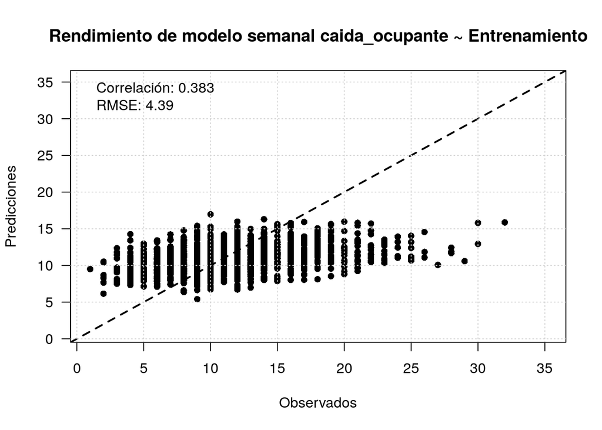

```r
y_pred <- exp(predict(step.model.caida_ocupante, df_caida_ocupante_train))
y_true <- exp(df_caida_ocupante_train$numero_accidentes)

train_rmse <- rmse(y_true, y_pred)

plot_estimation_errors(
  y_true = y_true,
  y_pred = y_pred,
  title="Rendimiento de modelo semanal caida_ocupante ~ Entrenamiento"
  )
```

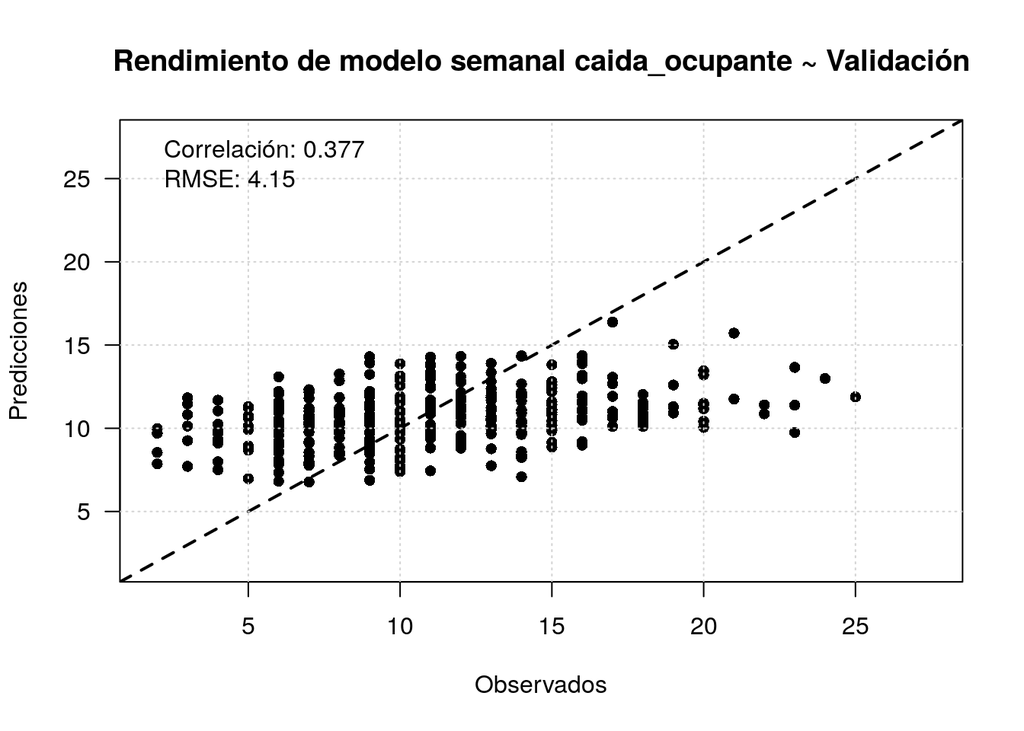

```r
y_pred <- exp(predict(step.model.caida_ocupante, df_caida_ocupante_test))
y_true <- exp(df_caida_ocupante_test$numero_accidentes)

train_rmse <- rmse(y_true, y_pred)

plot_estimation_errors(
  y_true = y_true,
  y_pred = y_pred,
  title="Rendimiento de modelo semanal caida_ocupante ~ Validación"
  )
```

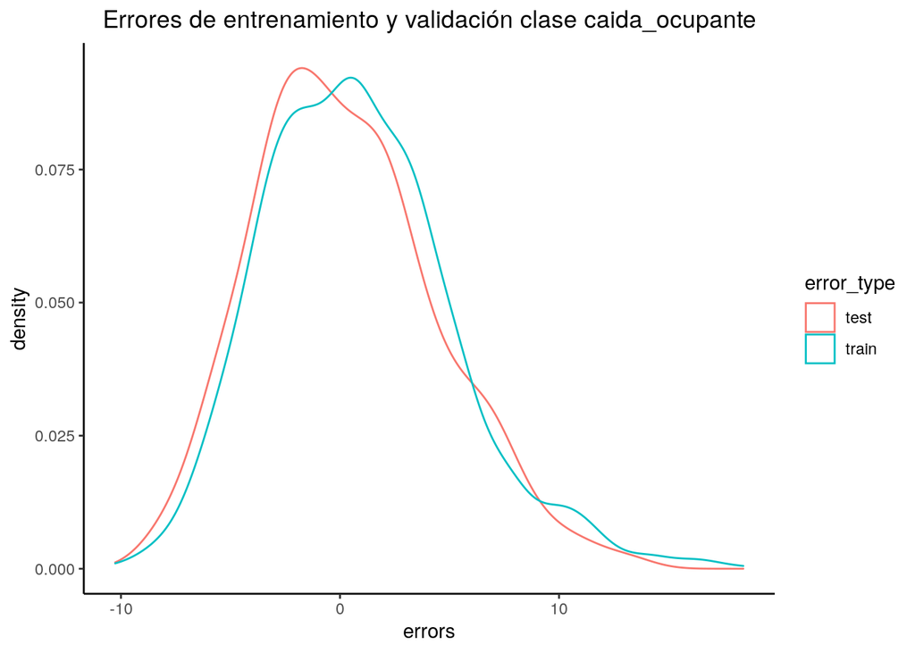

```r
plot_errors_density(
  model = step.model.caida_ocupante,
  train = df_caida_ocupante_train,
  y_train = df_caida_ocupante_train$numero_accidentes,
  test = df_caida_ocupante_test,
  y_test = df_caida_ocupante_test$numero_accidentes,
  title="Errores de entrenamiento y validación clase caida_ocupante"
  )
```

```r
df_preprocessed <- armado_dataset_diario(df=df, objective_var = "volcamiento")
df_volcamiento_train <- df_preprocessed %>% filter(PERIODO!=2018) %>% dplyr::select(-c(PERIODO, DIA))
df_volcamiento_test <- df_preprocessed %>% filter(PERIODO==2018) %>% dplyr::select(-c(PERIODO, DIA))

model.volcamiento.recipe <- recipe(numero_accidentes ~ .,
                              data = df_volcamiento_train)
model.volcamiento.steps <- model.volcamiento.recipe %>%
  step_log(all_outcomes()) %>%
  step_center(all_predictors(), -MES, -DIA_SEMANA, -DIA_FESTIVO, -FECHA_ESPECIAL, -FESTIVO_FECHA_ESPECIAL) %>%
  step_scale(all_predictors(), -MES, -DIA_SEMANA, -DIA_FESTIVO, -FECHA_ESPECIAL, -FESTIVO_FECHA_ESPECIAL)

model.volcamiento.prepared <- prep(model.volcamiento.steps, training = df_volcamiento_train)
df_volcamiento_train <- bake(model.volcamiento.prepared, df_volcamiento_train)
df_volcamiento_test <- bake(model.volcamiento.prepared, df_volcamiento_test)
```

```r
modelo.volcamiento <- lm(numero_accidentes ~ ., data=df_volcamiento_train)
step.model.volcamiento <- stepAIC(modelo.volcamiento, direction = "both", trace = F, steps = 2000)

model.volcamiento.summary <- summary(step.model.volcamiento)
model.volcamiento.summary
```

```
##
## Call:
## lm(formula = numero_accidentes ~ atropello + `caida ocupante` +
##     choque + volcamiento + t_minus_2 + t_minus_4 + t_minus_5 +
##     t_minus_6 + accidentes_tarde + DIA_SEMANA, data = df_volcamiento_train)
##
## Residuals:
##      Min       1Q   Median       3Q      Max
## -1.81718 -0.37373  0.05275  0.41719  1.45850
##
## Coefficients:
##                  Estimate Std. Error t value Pr(>|t|)
## (Intercept)       1.09706    0.04323  25.376  < 2e-16 ***
## atropello        -0.02578    0.01671  -1.543 0.123003
## `caida ocupante` -0.02592    0.01670  -1.552 0.120915
## choque            0.07664    0.02308   3.321 0.000921 ***
## volcamiento       0.04422    0.01659   2.666 0.007774 **
## t_minus_2         0.06551    0.01647   3.977 7.34e-05 ***
## t_minus_4         0.03391    0.01654   2.050 0.040511 *
## t_minus_5         0.03176    0.01633   1.944 0.052052 .
## t_minus_6         0.03290    0.01648   1.996 0.046151 *
## accidentes_tarde -0.03335    0.01776  -1.878 0.060623 .
## DIA_SEMANA2       0.39940    0.06813   5.863 5.69e-09 ***
## DIA_SEMANA3       0.28482    0.06135   4.642 3.77e-06 ***
## DIA_SEMANA4       0.26446    0.06089   4.343 1.51e-05 ***
## DIA_SEMANA5       0.30045    0.06138   4.895 1.10e-06 ***
## DIA_SEMANA6       0.22403    0.06101   3.672 0.000250 ***
## DIA_SEMANA7       0.21282    0.06132   3.470 0.000536 ***
## ---
## Signif. codes:  0 '***' 0.001 '**' 0.01 '*' 0.05 '.' 0.1 ' ' 1
##
## Residual standard error: 0.5945 on 1390 degrees of freedom
## Multiple R-squared:  0.08012,    Adjusted R-squared:  0.0702
## F-statistic: 8.072 on 15 and 1390 DF,  p-value: < 2.2e-16
```

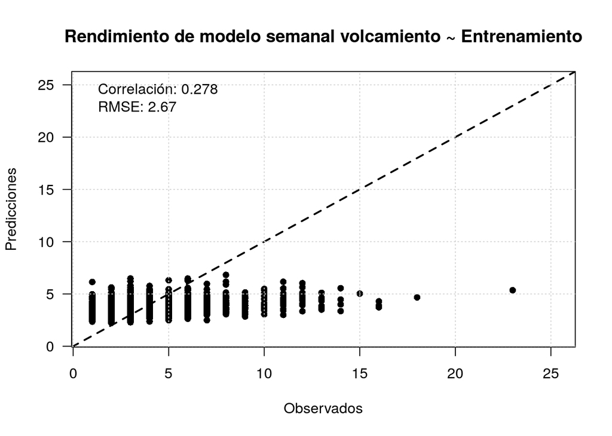

```r
y_pred <- exp(predict(step.model.volcamiento, df_volcamiento_train))
y_true <- exp(df_volcamiento_train$numero_accidentes)

train_rmse <- rmse(y_true, y_pred)

plot_estimation_errors(
  y_true = y_true,
  y_pred = y_pred,
  title="Rendimiento de modelo semanal volcamiento ~ Entrenamiento"
  )
```

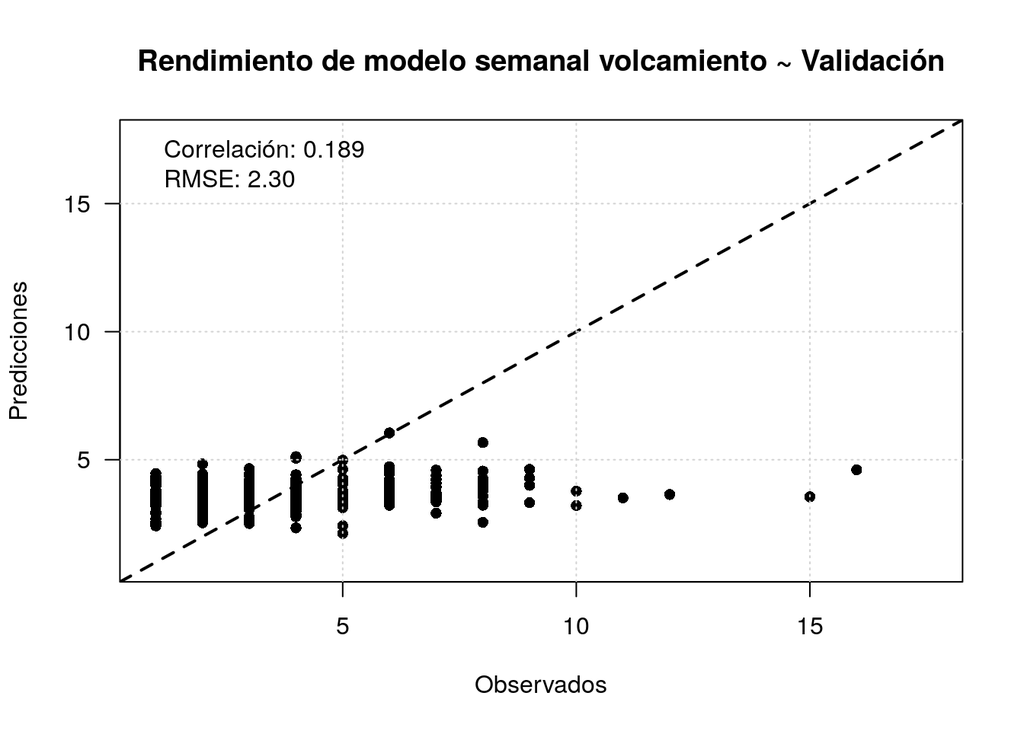

```r
y_pred <- exp(predict(step.model.volcamiento, df_volcamiento_test))
y_true <- exp(df_volcamiento_test$numero_accidentes)

train_rmse <- rmse(y_true, y_pred)

plot_estimation_errors(
  y_true = y_true,
  y_pred = y_pred,
  title="Rendimiento de modelo semanal volcamiento ~ Validación"
  )
```

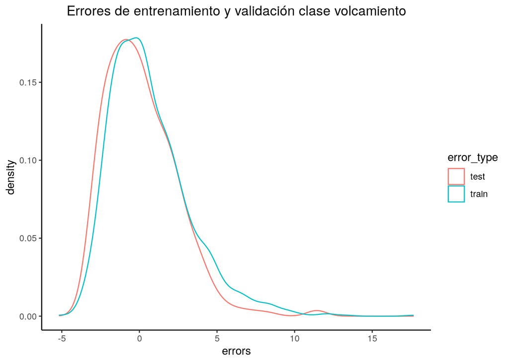

```r
plot_errors_density(
  model = step.model.volcamiento,
  train = df_volcamiento_train,
  y_train = df_volcamiento_train$numero_accidentes,
  test = df_volcamiento_test,
  y_test = df_volcamiento_test$numero_accidentes,
  title="Errores de entrenamiento y validación clase volcamiento"
  )
```

### Clase otros accidentes

#### Regresión lineal

```r
df_preprocessed <- armado_dataset_diario(df=df, objective_var = "otro")
df_otro_train <- df_preprocessed %>% filter(PERIODO!=2018) %>% dplyr::select(-c(PERIODO, DIA))
df_otro_test <- df_preprocessed %>% filter(PERIODO==2018) %>% dplyr::select(-c(PERIODO, DIA))

model.otro.recipe <- recipe(numero_accidentes ~ .,
                              data = df_otro_train)
model.otro.steps <- model.otro.recipe %>%
  step_log(all_outcomes()) %>%
  step_center(all_predictors(), -MES, -DIA_SEMANA, -DIA_FESTIVO, -FECHA_ESPECIAL, -FESTIVO_FECHA_ESPECIAL) %>%
  step_scale(all_predictors(), -MES, -DIA_SEMANA, -DIA_FESTIVO, -FECHA_ESPECIAL, -FESTIVO_FECHA_ESPECIAL)

model.otro.prepared <- prep(model.otro.steps, training = df_otro_train)
df_otro_train <- bake(model.otro.prepared, df_otro_train)
df_otro_test <- bake(model.otro.prepared, df_otro_test)
```

```r
modelo.otro <- lm(numero_accidentes ~ ., data=df_otro_train)
step.model.otro <- stepAIC(modelo.otro, direction = "both", trace = F, steps = 2000)

model.otro.summary <- summary(step.model.otro)
model.otro.summary
```

```
##
## Call:
## lm(formula = numero_accidentes ~ MES + choque + otro + t_minus_2 +
##     t_minus_3 + t_minus_4 + DIA_FESTIVO + accidentes_tarde +
##     DIA_SEMANA, data = df_otro_train)
##
## Residuals:
##      Min       1Q   Median       3Q      Max
## -1.82171 -0.21817  0.03722  0.24910  1.04217
##
## Coefficients:
##                  Estimate Std. Error t value Pr(>|t|)
## (Intercept)       2.28306    0.04387  52.040  < 2e-16 ***
## MES2              0.16437    0.05169   3.180 0.001505 **
## MES3              0.15434    0.05058   3.052 0.002318 **
## MES4              0.07430    0.05016   1.481 0.138773
## MES5              0.21359    0.05087   4.199 2.85e-05 ***
## MES6              0.12814    0.05030   2.547 0.010957 *
## MES7              0.15588    0.05004   3.115 0.001876 **
## MES8              0.17843    0.05124   3.483 0.000511 ***
## MES9              0.15268    0.05136   2.973 0.002998 **
## MES10             0.14958    0.05065   2.953 0.003199 **
## MES11             0.08308    0.05057   1.643 0.100653
## MES12             0.08288    0.05033   1.647 0.099802 .
## choque           -0.02636    0.01469  -1.794 0.072964 .
## otro              0.03575    0.01070   3.340 0.000859 ***
## t_minus_2         0.02047    0.01053   1.944 0.052050 .
## t_minus_3         0.02508    0.01052   2.383 0.017291 *
## t_minus_4         0.02056    0.01049   1.960 0.050140 .
## DIA_FESTIVO1     -0.22394    0.04730  -4.734 2.42e-06 ***
## accidentes_tarde  0.02591    0.01174   2.207 0.027504 *
## DIA_SEMANA2       0.23515    0.04335   5.424 6.83e-08 ***
## DIA_SEMANA3       0.27365    0.03836   7.134 1.55e-12 ***
## DIA_SEMANA4       0.26011    0.03898   6.673 3.57e-11 ***
## DIA_SEMANA5       0.27949    0.03840   7.278 5.56e-13 ***
## DIA_SEMANA6       0.22559    0.03771   5.983 2.77e-09 ***
## DIA_SEMANA7       0.05995    0.03818   1.570 0.116571
## ---
## Signif. codes:  0 '***' 0.001 '**' 0.01 '*' 0.05 '.' 0.1 ' ' 1
##
## Residual standard error: 0.3799 on 1430 degrees of freedom
## Multiple R-squared:  0.1287, Adjusted R-squared:  0.1141
## F-statistic: 8.803 on 24 and 1430 DF,  p-value: < 2.2e-16
```

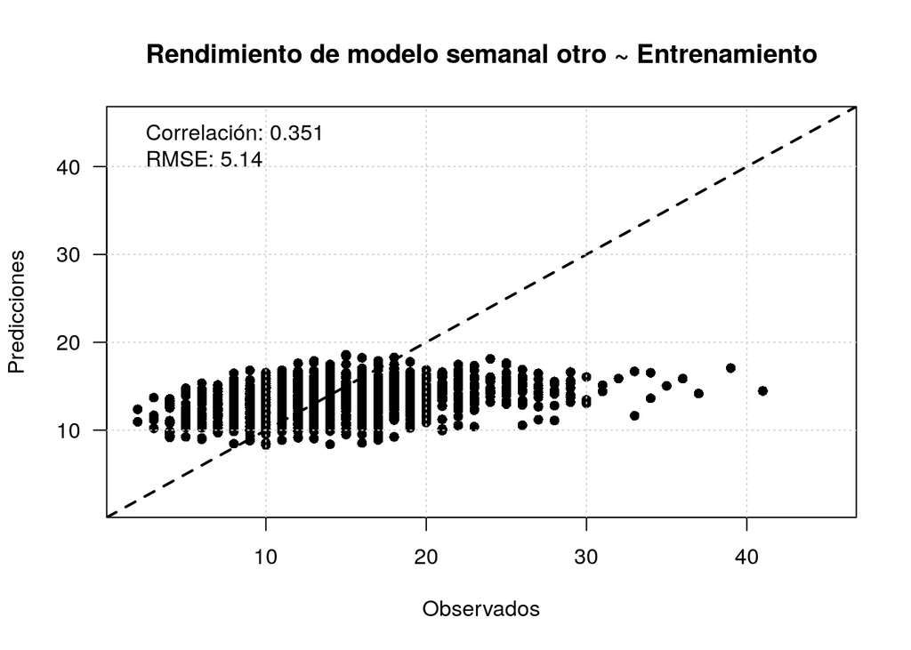

```r
y_pred <- exp(predict(step.model.otro, df_otro_train))
y_true <- exp(df_otro_train$numero_accidentes)

train_rmse <- rmse(y_true, y_pred)

plot_estimation_errors(
  y_true = y_true,
  y_pred = y_pred,
  title="Rendimiento de modelo semanal otro ~ Entrenamiento"
  )
```

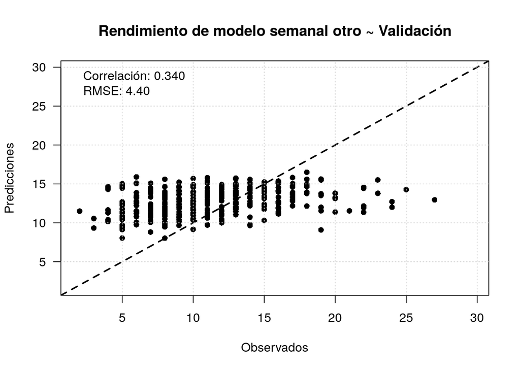

```r
y_pred <- exp(predict(step.model.otro, df_otro_test))
y_true <- exp(df_otro_test$numero_accidentes)

train_rmse <- rmse(y_true, y_pred)

plot_estimation_errors(
  y_true = y_true,
  y_pred = y_pred,
  title="Rendimiento de modelo semanal otro ~ Validación"
  )
```

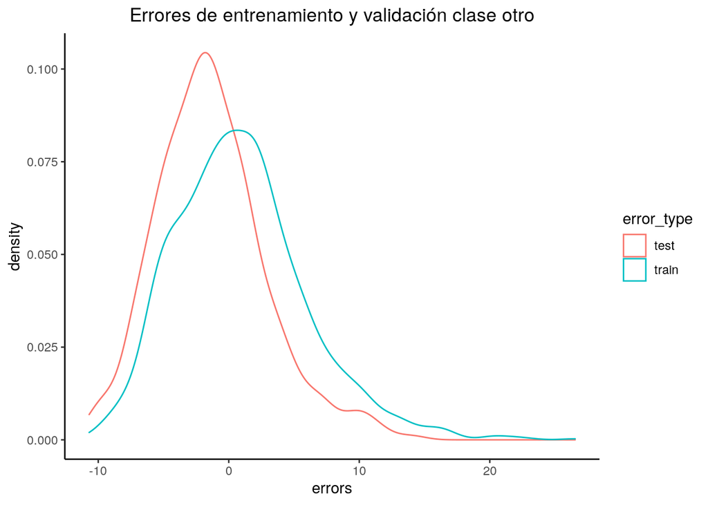

```r
plot_errors_density(
  model = step.model.otro,
  train = df_otro_train,
  y_train = df_otro_train$numero_accidentes,
  test = df_otro_test,
  y_test = df_otro_test$numero_accidentes,
  title="Errores de entrenamiento y validación clase otro"
  )
```